# assignment 1

Oyedayo Oyelowo

2 November 2017

## Exercise 1

- 1. Form three separate vectors from scalars 4,5 and 33; -48, 0 and 45; 7, 3 and 1
- 2. Combine vectors into one 3x3 matrix
- 3. Name rows of the matrix as r1, r2 and r3. Name columns of the matrix as A, B and C

```r
a<-c(4, 5, 33)
b<-c(-48, 0, 45)
c<-c(7, 3, 1)

m=matrix(c(a,b,c), ncol=3, nrow = 3, byrow = TRUE)
rownames(m) <- c("r1","r2","r3")
colnames(m) <- c("A", "B", "C")
m
```

```
##      A B  C
## r1   4 5 33
## r2 -48 0 45
## r3   7 3  1
```

## Exercise 2

- Generate the following vectors with functions rep() and seq()
- 1. [0 0 0 0 0 1 1 1 1 1 2 2 2 2 2 3 3 3 3 3 4 4 4 4 4]

```r
rep(0:4, rep(5,5))
```

```
##  [1] 0 0 0 0 0 1 1 1 1 1 2 2 2 2 2 3 3 3 3 3 4 4 4 4 4
```

```r
rep(0:4, each=5)
```

```
##  [1] 0 0 0 0 0 1 1 1 1 1 2 2 2 2 2 3 3 3 3 3 4 4 4 4 4
```

- 2. [1 2 3 4 5 1 2 3 4 5 1 2 3 4 5 1 2 3 4 5 1 2 3 4 5]

```r
#y <- seq(0:4)
#y
rep(1:5, rep(5,5), length.out=25)
```

```
##  [1] 1 2 3 4 5 1 2 3 4 5 1 2 3 4 5 1 2 3 4 5 1 2 3 4 5
```

```r
##or
rep(seq(0:4), rep(5,5), length.out=25)
```

```
##  [1] 1 2 3 4 5 1 2 3 4 5 1 2 3 4 5 1 2 3 4 5 1 2 3 4 5
```

## Exercise 3

- Solar radiation was measured in a greenhouse at eight different times. Observations were 11.1, 10.6, 6.3, 8.8, 10.7, 11.2, 8.9 and 12.2 units.
- 1. Save measurements as variable solar.radiation (set value with a vector containing all measurements)
- 2. Define mean, median and variance of variable solar.radiation (with pre-determined R-functions)

```r
solar.radiation <- c(11.1, 10.6, 6.3, 8.8, 10.7, 11.2, 8.9, 12.2)


mean(solar.radiation)
```

```
## [1] 9.975
```

```r
median(solar.radiation)
```

```
## [1] 10.65
```

```r
var(solar.radiation)
```

```
## [1] 3.525
```

- 3. Add value 10 to every observation and name the new vector as sr10. Define mean, median and variance of modified vector. Which of the determined values changed from the previous and how much?

```r
sr10 = solar.radiation + 10
sr10
```

```
## [1] 21.1 20.6 16.3 18.8 20.7 21.2 18.9 22.2
```

```r
mean(sr10)
```

```
## [1] 19.975
```

```r
median(sr10)
```

```
## [1] 20.65
```

```r
var(sr10)
```

```
## [1] 3.525
```

*the mean and the median changed and increased by 10 from the previous values while the variance remained the same at 3.525*

- **d) Multiply the original observations by -2 and name the resulting vector as srm2. What happened to mean, median and variance?**

```r
srm2=solar.radiation * -2
srm2
```

```
## [1] -22.2 -21.2 -12.6 -17.6 -21.4 -22.4 -17.8 -24.4
```

```r
mean(srm2)
```

```
## [1] -19.95
```

```r
median(srm2)
```

```
## [1] -21.3
```

```r
var(srm2)
```

```
## [1] 14.1
```

*the mean became a negative value of -19.95, the median also became a negative value of -21.3 while the variance remained positive value but higher at 14.1*

- **e) Variance is generally determined with following formulas:**
- **Which of the two is used in R-function var()?**

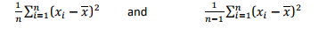

variance formula.

# The second is being used in R-function variance i.e b.

## Exercise 4

- Generate 25 random integers from interval [1,100] and place them in row-wise in 5x5 matrice.

```r
rand=ceiling(runif(25, 1, 100))
rand
```

```
##  [1]  73   3  67  67  25  16  48  36  26  13  26 100  67  18  84  73  60
## [18]  54  45  29  41  46  52  14  43
```

```r
mat=matrix(rand, ncol=5, nrow=5, byrow=T)
mat
```

```
##      [,1] [,2] [,3] [,4] [,5]
## [1,]   73    3   67   67   25
## [2,]   16   48   36   26   13
## [3,]   26  100   67   18   84
## [4,]   73   60   54   45   29
## [5,]   41   46   52   14   43
```

```r
#a) Name the rows as r1-r5 and the columns as c1-c5
rownames(mat) <- c("r1","r2","r3","r4","r5")
colnames(mat) <- c("c1","c2","c3","c4","c5")
mat
```

```
##    c1  c2 c3 c4 c5
## r1 73   3 67 67 25
## r2 16  48 36 26 13
## r3 26 100 67 18 84
## r4 73  60 54 45 29
## r5 41  46 52 14 43
```

- **b) Determine the sum of numbers in the matrice**’
- **c) Substract the minimum of the matrice from every other figure in the Matrix**
- **d) Print the figure that is in column 3 of row 4**

```r
sum(mat)
```

```
## [1] 1126
```

```r
mat2=mat - min(mat)
mat2
```

```
##    c1 c2 c3 c4 c5
## r1 70  0 64 64 22
## r2 13 45 33 23 10
## r3 23 97 64 15 81
## r4 70 57 51 42 26
## r5 38 43 49 11 40
```

```r
mat2[4,3]
```

```
## [1] 51
```

## Exercise 5

- **Search the internet for information on function getEventProb.**
- 1. To which R-package does the function belong?
- answer: *It belongs to the package “dice”*
- 2. What does the function actually do?
- answer: *It calculates the probability of a specified set of dice-rolling events*
- 3. With which parameters can you control the function?
- You can control the function with the following parameters:
- **nrolls, ndicePerRoll, nsidesPerDie, eventList, orderMatters = FALSE)**
- **Arguments**
- **nrolls:** A single positive integer representing the number of dice rolls to make
- **ndicePerRoll:** A single positive integer representing the number of dice to use in each dice roll
- **nsidesPerDie:** A single positive integer representing the number of sides on each die (getEventProb’s dice-rolling process involves only one type of die per call)
- **eventList:** A list object, each element of which is a vector that constrains a single dice roll in the dice-rolling process (see Details below)
- **orderMatters**: A logical flag indicating whether the order of the elements of eventList should constrain the event space; if TRUE, eventList must specify constraints for every dice roll-i.e., it must contain exactly nrolls elements (some of which may be “empty” constraints listing all possible outcomes of a dice roll, i.e., a vector from ndicePerRoll to (ndicePerRoll * nsidesPerDie))
- **Download the package to your computer and activate it from the R-library. Then, answer to following questions with help of the tools found in the package.**
- 4. What are the odds that a throw with two 6-sided dice results sum of 7?

```r
#install.packages("dice")
library(dice)
odds1<-getEventProb(nrolls = 1, ndicePerRoll = 2, nsidesPerDie = 6, eventList = list(7), orderMatters = F)
print(paste("The odds that a throw with two 6-sided dice results sum of 7 is", round(odds1,4)))
```

```
## [1] "The odds that a throw with two 6-sided dice results sum of 7 is 0.1667"
```

- 5. What are the odds that a throw with two 10-sided dice results two tens? (the sum of dice is 20)?

```r
odds2<-getEventProb(nrolls = 1, ndicePerRoll = 2, nsidesPerDie = 10, eventList = list(20))
print(paste("the odds that a throw with two 10-sided dice results two tens (the sum of dice is 20) is",  round(odds2,4)))
```

```
## [1] "the odds that a throw with two 10-sided dice results two tens (the sum of dice is 20) is 0.01"
```